# Lesson 4 - basic R plotting

Mik Black

3 February 2016

## R graphics

- R provides multiple “systems” for producing graphics
- We’re going to focus on the oldest (and arguably easiest) of these: R base graphics
- These capabilities are included with base R (i.e., what you get when you install the R software), and don’t require any additional packages to be loaded.

## But first… data summaries

- One of the reasons for generating plots is to produce a visual summary of the data
  - this helps us (and ohers) to understand key features such as *centre* and *spread*.
- In addition to graphical methods, we can also use tools to produce numerical summaries of this information.
  - For example: mean, median, standard deviation, variance, range, min, max, interquartile range…

## Examples: non-graphical data summaries

```r
## Lets load the data and take a look at it first
data <- read.csv('patient_data.csv')

## What type of object have we created?
class(data)
```

```
## [1] "data.frame"
```

```r
## What are its dimensions?
dim(data)
```

```
## [1] 1000    9
```

```r
## What are the variable names?
names(data)
```

```
## [1] "PATIENT"     "AGECOL"      "SEX"         "DIABETES"    "URATE"
## [6] "BMI"         "GOUTAFFSTAT" "ETHCLASS"    "SNP"
```

```r
## What do the first few rows look like?
head(data)
```

```
##   PATIENT AGECOL SEX DIABETES URATE   BMI GOUTAFFSTAT ETHCLASS SNP
## 1       1     36   1        1  0.41    NA          NA        1   3
## 2       2     43   1        1    NA 56.19           1        3   2
## 3       3     NA   1        1    NA    NA           1        1   3
## 4       4     NA   1        1  0.32 25.00           1        1   2
## 5       5     31   1        1  0.40 33.61           1        1   2
## 6       6     46   2        1 31.00    NA           2        3   2
```

```r
## What does the start of the BMI variable look like?
## (note the use of the $ operator to access the BMI information from the data object)
head(data$BMI)
```

```
## [1]    NA 56.19    NA 25.00 33.61    NA
```

```r
## What if we "attach" the data?
attach(data)

## Look, no more $ sign!
head(BMI)
```

```
## [1]    NA 56.19    NA 25.00 33.61    NA
```

```r
## Summarize the entire data frame
summary(data)
```

```
##     PATIENT           AGECOL        SEX          DIABETES
##  Min.   :   1.0   Min.   :17   Min.   :1.00   Min.   :1.000
##  1st Qu.: 250.8   1st Qu.:39   1st Qu.:1.00   1st Qu.:1.000
##  Median : 500.5   Median :52   Median :1.00   Median :1.000
##  Mean   : 500.5   Mean   :51   Mean   :1.36   Mean   :1.139
##  3rd Qu.: 750.2   3rd Qu.:63   3rd Qu.:2.00   3rd Qu.:1.000
##  Max.   :1000.0   Max.   :95   Max.   :2.00   Max.   :2.000
##                   NA's   :62   NA's   :49     NA's   :115
##      URATE             BMI         GOUTAFFSTAT       ETHCLASS
##  Min.   : 0.124   Min.   :17.58   Min.   :1.000   Min.   :1.000
##  1st Qu.: 0.340   1st Qu.:26.85   1st Qu.:1.000   1st Qu.:1.000
##  Median : 0.410   Median :30.84   Median :1.000   Median :1.000
##  Mean   : 1.080   Mean   :32.16   Mean   :1.437   Mean   :2.092
##  3rd Qu.: 0.500   3rd Qu.:35.73   3rd Qu.:2.000   3rd Qu.:2.000
##  Max.   :55.300   Max.   :70.32   Max.   :2.000   Max.   :9.000
##  NA's   :170      NA's   :228     NA's   :57
##       SNP
##  Min.   :1.000
##  1st Qu.:2.000
##  Median :2.000
##  Mean   :2.296
##  3rd Qu.:3.000
##  Max.   :3.000
##
```

```r
## Summarize just the BMI variable
summary(BMI)
```

```
##    Min. 1st Qu.  Median    Mean 3rd Qu.    Max.    NA's
##   17.58   26.85   30.84   32.16   35.73   70.32     228
```

```r
## Calculate the mean of the BMI variable
mean(BMI)
```

```
## [1] NA
```

```r
## Oops, we need to get rid of the NA values
mean(BMI,na.rm=T)
```

```
## [1] 32.15743
```

```r
## Calculate the mean of the BMI variable
median(BMI, na.rm=T)
```

```
## [1] 30.84
```

```r
## Calculate the standard deviation of the BMI variable
sd(BMI, na.rm=T)
```

```
## [1] 7.516478
```

## Other summaries

- the above are just a few summaries that can be produced.
  - try: IQR, max, min, range…
- We can also summarize categorical data using tables via the `table` command.
  - `prop.table` can then be used to calculate proportions.

```r
## Make a table of the ethnicity data
## Note that information class labels can be a good thing...
table(ETHCLASS)
```

```
## ETHCLASS
##   1   2   3   9
## 502 258 181  59
```

```r
## Include the NA information
table(ETHCLASS, useNA = 'always')
```

```
## ETHCLASS
##    1    2    3    9 <NA>
##  502  258  181   59    0
```

```r
## Diabetes status
table(DIABETES)
```

```
## DIABETES
##   1   2
## 762 123
```

```r
## Two-way table of ethnicity and diabetes
table(ETHCLASS, DIABETES)
```

```
##         DIABETES
## ETHCLASS   1   2
##        1 397  55
##        2 184  40
##        3 139  18
##        9  42  10
```

```r
## Add dimension names
table(ETHCLASS, DIABETES, dnn = c("Ethnicity","Diabetes"))
```

```
##          Diabetes
## Ethnicity   1   2
##         1 397  55
##         2 184  40
##         3 139  18
##         9  42  10
```

```r
## We can also flip this via the transpose operator:
t( table(ETHCLASS, DIABETES) )
```

```
##         ETHCLASS
## DIABETES   1   2   3   9
##        1 397 184 139  42
##        2  55  40  18  10
```

```r
## Use the prop.table command to calculate proportions (cells sum to 1):
prop.table( table(ETHCLASS, DIABETES) )
```

```
##         DIABETES
## ETHCLASS          1          2
##        1 0.44858757 0.06214689
##        2 0.20790960 0.04519774
##        3 0.15706215 0.02033898
##        9 0.04745763 0.01129944
```

```r
## You can also calculate proportions across rows (rows sum to 1):
prop.table( table(ETHCLASS, DIABETES), 1 )
```

```
##         DIABETES
## ETHCLASS         1         2
##        1 0.8783186 0.1216814
##        2 0.8214286 0.1785714
##        3 0.8853503 0.1146497
##        9 0.8076923 0.1923077
```

```r
## or down columns (columns sum to 1):
prop.table( table(ETHCLASS, DIABETES), 2 )
```

```
##         DIABETES
## ETHCLASS          1          2
##        1 0.52099738 0.44715447
##        2 0.24146982 0.32520325
##        3 0.18241470 0.14634146
##        9 0.05511811 0.08130081
```

## Plotting

- Need to use the right sort of plot for the data we have
  - One continuous variable: histogram (`hist`), boxplot (`boxplot`), density plot (`plot` and `density` - see below)
  - Two continuous variabes: scatterplot (`plot`)
  - One (or more) cateogircal variables: barplots (`barplot`)
  - One continuous and one (or more) categorical variable: boxplots (`boxplot`)

## Histograms - single continuous variable

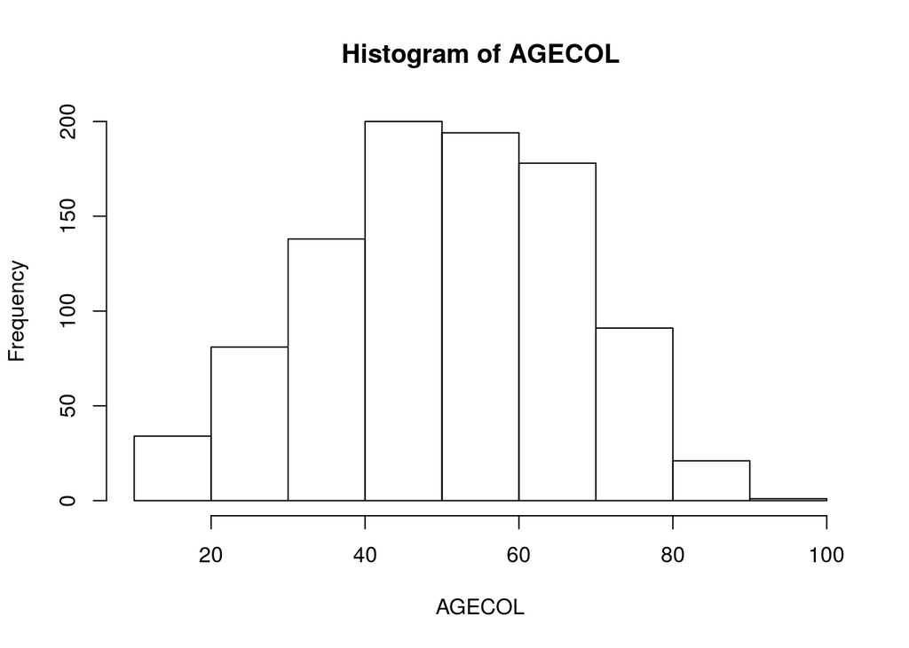

```r
## Generate histogram of age data
hist( AGECOL )
```

## Making plots prettier

- most base R plotting methods share parameters relating to plot aesthetics (e.g., axis labels/limits, title, text size, plotting colours etc)
- this makes it very easy to customize plots, and may them look fairly nice

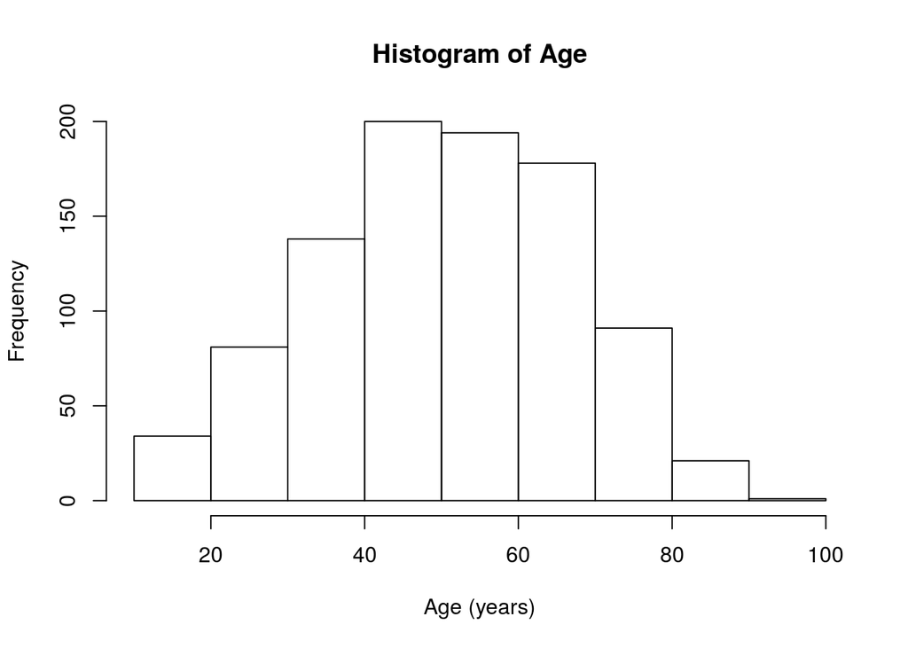

```r
## Add title and axis labels
hist( AGECOL , main = "Histogram of Age", xlab = "Age (years)")
```

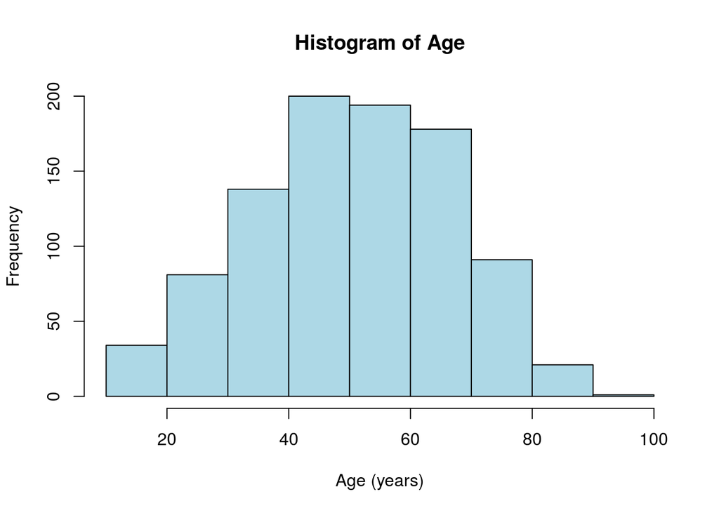

```r
##Add some colour...
hist( AGECOL , main = "Histogram of Age", xlab = "Age (years)", col='lightblue')
```

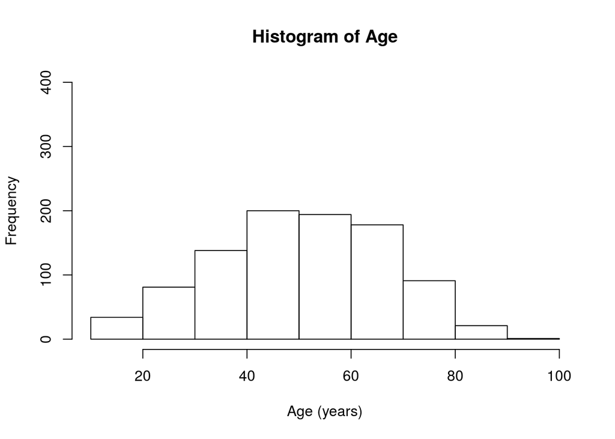

```r
## Extend y axis
hist( AGECOL , main = "Histogram of Age", xlab = "Age (years)", ylim = c(0,400))
```

## Boxplots - single continuous variable

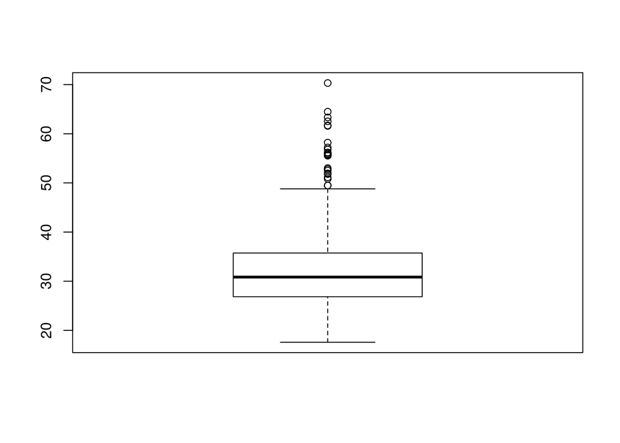

```r
## Boxplot of BMI
boxplot(BMI)
```

## Boxplots - continuous & categorical variables

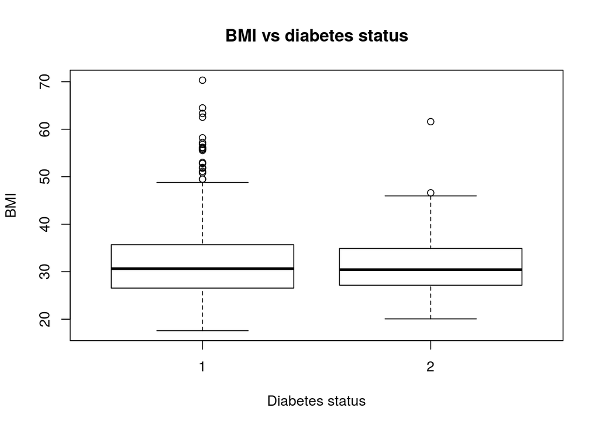

```r
## Boxplot of BMI vs Diabetes Status
boxplot(BMI ~ DIABETES, xlab = "Diabetes status", ylab = "BMI", main = "BMI vs diabetes status")
```

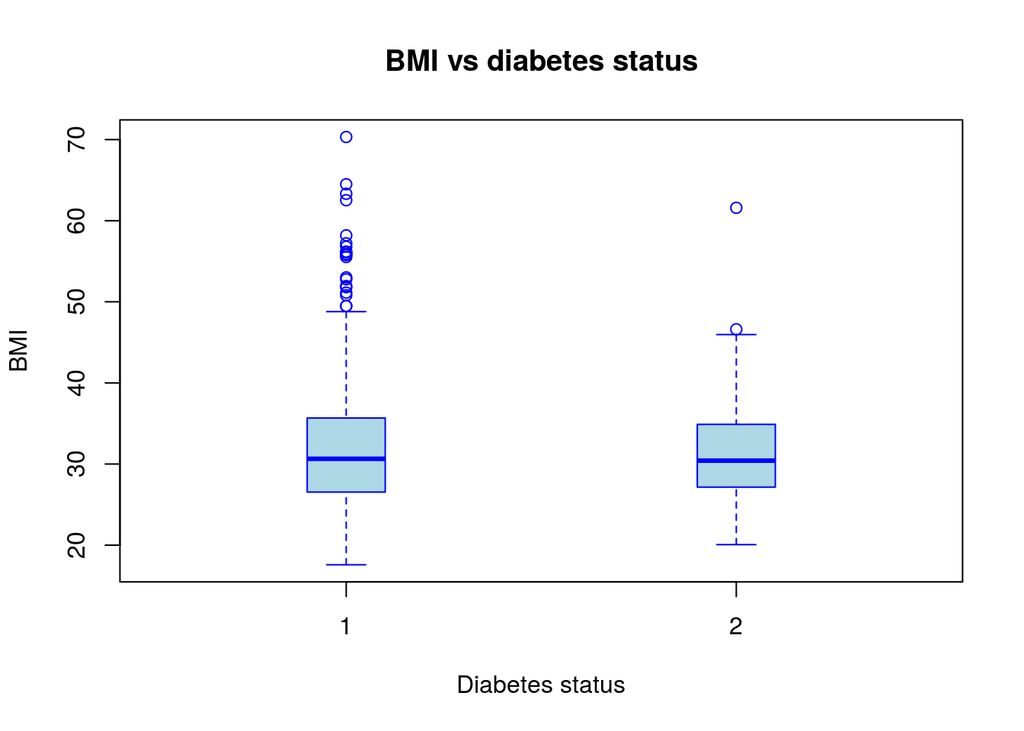

````r
## Change the colours and box widths
## Note: ```col``` defines the box colour, and ```border``` defines the border colour
boxplot(BMI ~ DIABETES, xlab = "Diabetes status", ylab = "BMI", main = "BMI vs diabetes status",
        boxwex = 0.2, col = "lightblue", border = "blue")
````

## Scatterplots - two continuous variables

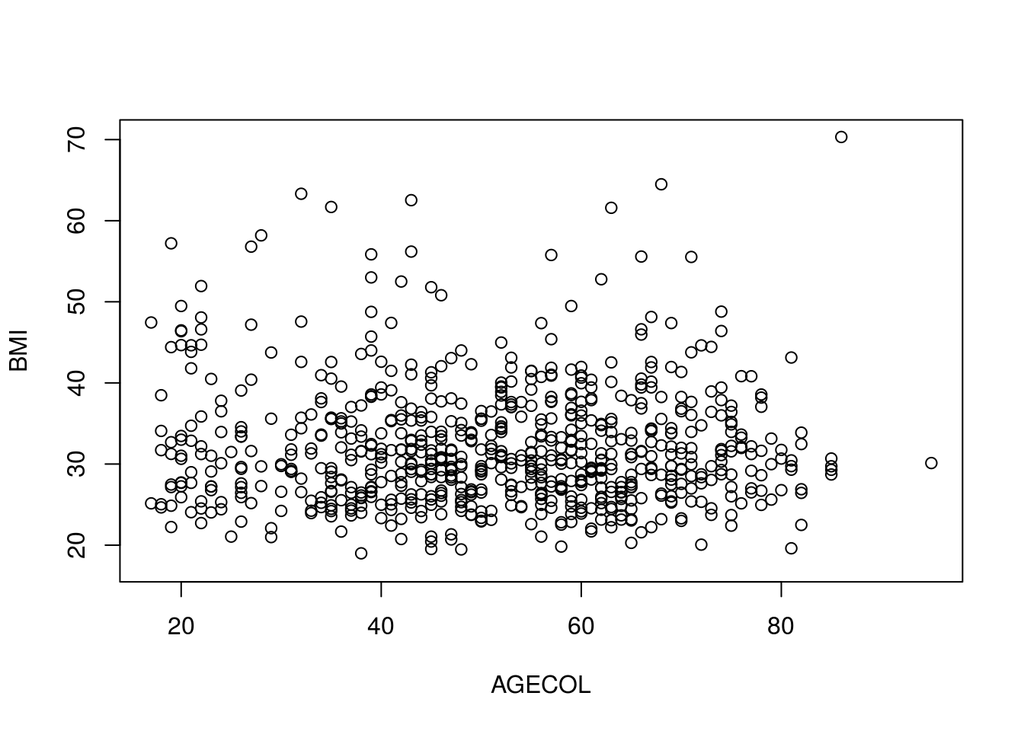

```r
## Scatterplot of Age vs BMI
plot(AGECOL, BMI)
```

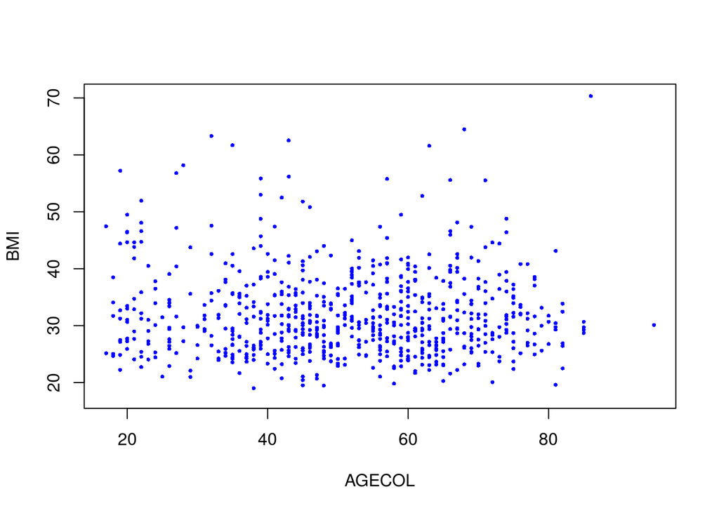

```r
## Change plotting symbol, size and colour
plot(AGECOL, BMI, pch = 16, col = "blue", cex = 0.5)
```

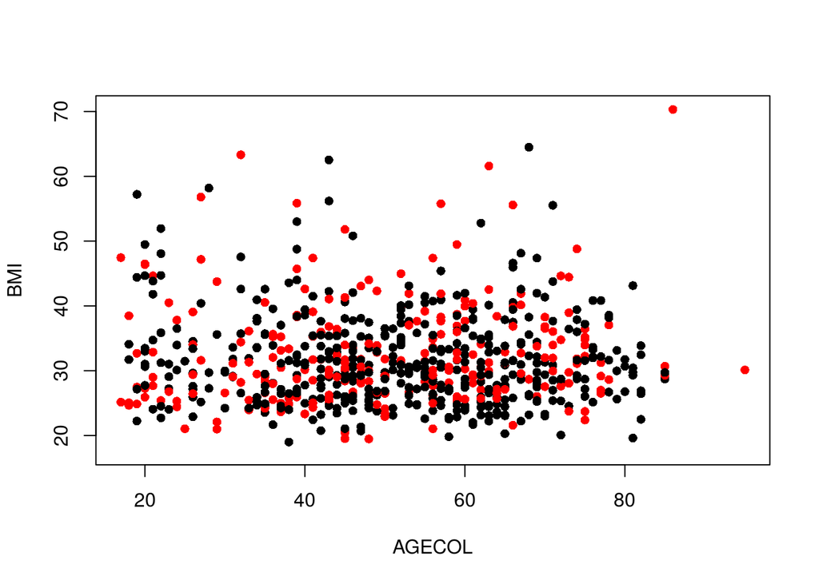

```r
## Use SEX variable to denote colour (has to be numeric, or actual colours)
## R colours are: 1 = black, 2 = red, 3 = green, 4 = blue, 5 = cyan, 6 = magenta,
##                7 = yellow, 8 = grey, 9 = black, 0 = white
plot(AGECOL, BMI, col = SEX, pch = 16)
```

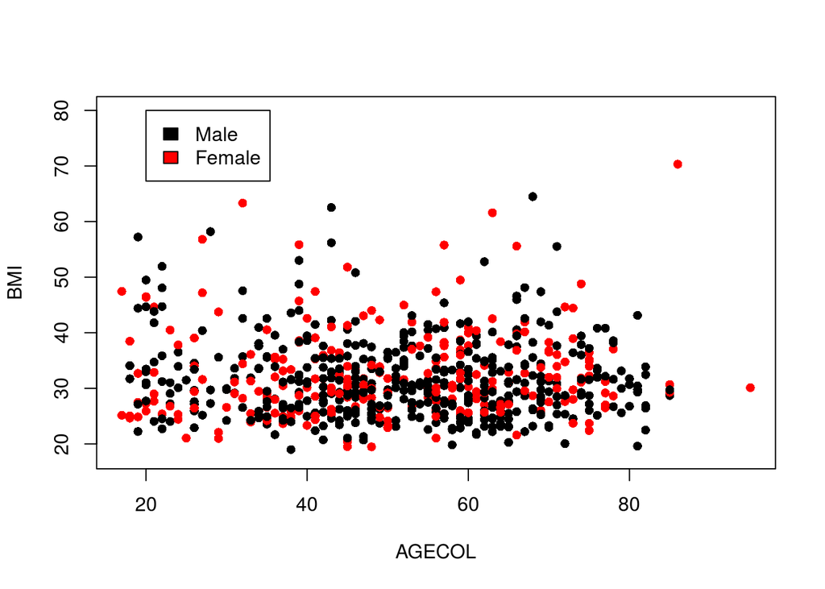

```r
## Adjust y axis limits and add a legend
plot(AGECOL, BMI, col = SEX, pch = 16, ylim = c(18, 80))
legend(20, 80, c("Male", "Female"), fill = c("black","red"))
```

## Barplots - one or more categorical variables

```r
## Summarize ethinicty data as a table:
table(ETHCLASS)
```

```
## ETHCLASS
##   1   2   3   9
## 502 258 181  59
```

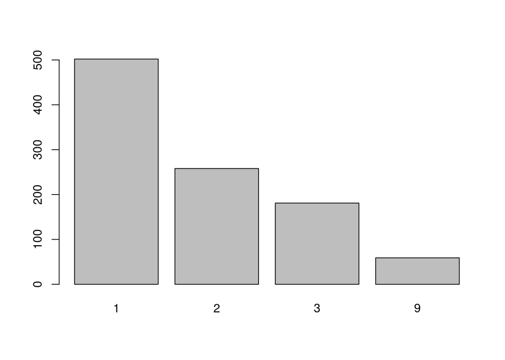

```r
## Represent this information as a barplot
barplot( table(ETHCLASS) )
```

```r
## Generate 2-way tabe for ethnicity and diabetes
table(ETHCLASS, DIABETES)
```

```
##         DIABETES
## ETHCLASS   1   2
##        1 397  55
##        2 184  40
##        3 139  18
##        9  42  10
```

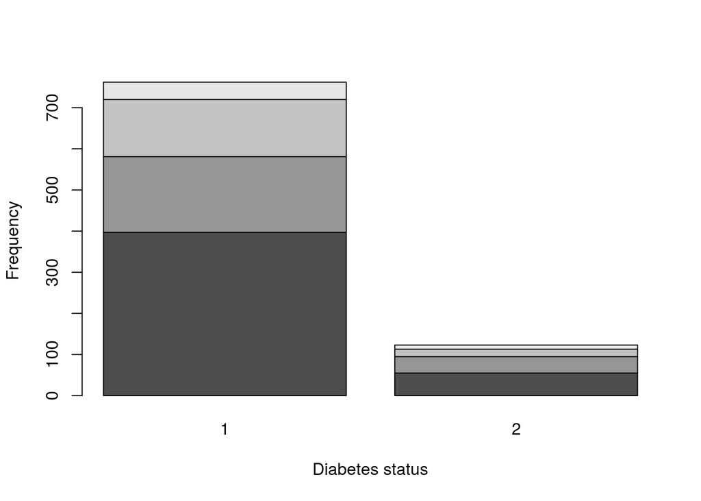

```r
## Represent this information as a (stacked) barplot
barplot( table(ETHCLASS, DIABETES), xlab = "Diabetes status", ylab = "Frequency" )
```

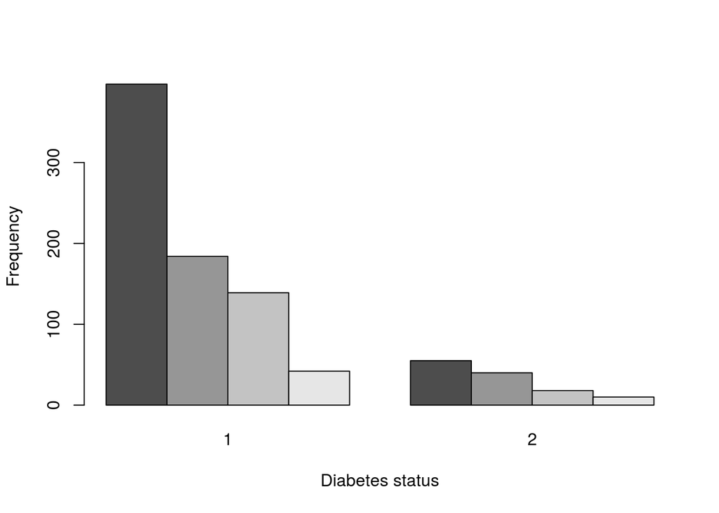

```r
## Same information, unstacked
barplot( table(ETHCLASS, DIABETES), xlab = "Diabetes status", ylab = "Frequency", beside = TRUE )
```

```r
## What is we want to look at it the other way around?
## Use the transpose function, t(), to flip the table
t( table(ETHCLASS, DIABETES) )
```

```
##         ETHCLASS
## DIABETES   1   2   3   9
##        1 397 184 139  42
##        2  55  40  18  10
```

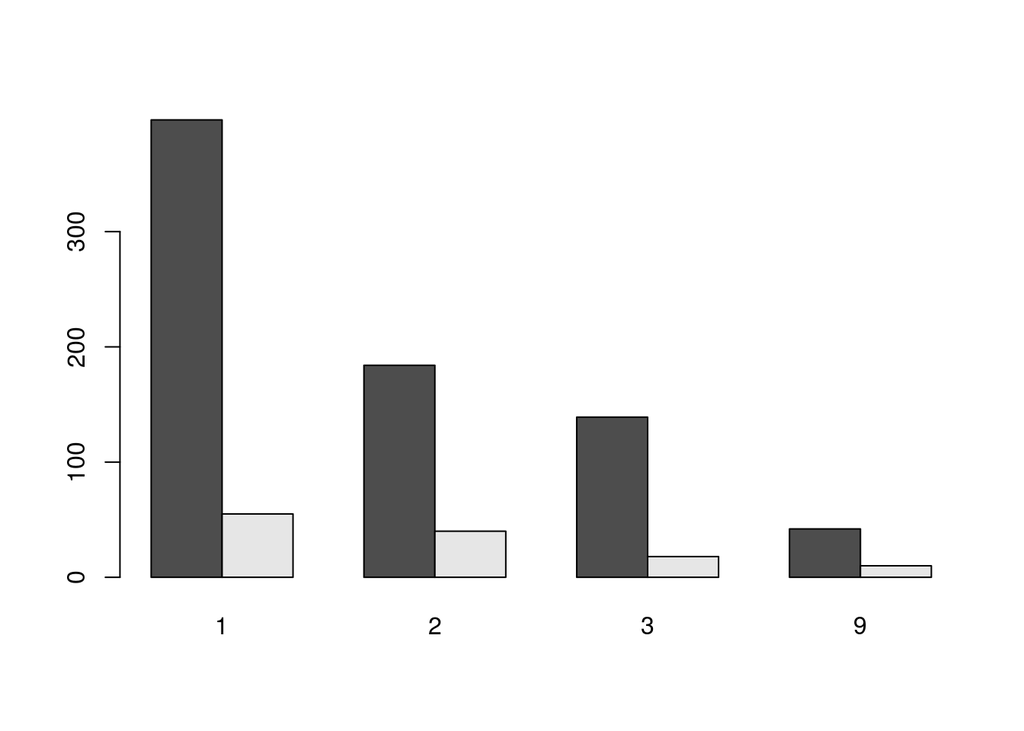

```r
## Then make a barplot
barplot( t(table(ETHCLASS, DIABETES)), beside = TRUE )
```

```r
## What if we're more interested in proportions?
prop.table( table(ETHCLASS, DIABETES) )
```

```
##         DIABETES
## ETHCLASS          1          2
##        1 0.44858757 0.06214689
##        2 0.20790960 0.04519774
##        3 0.15706215 0.02033898
##        9 0.04745763 0.01129944
```

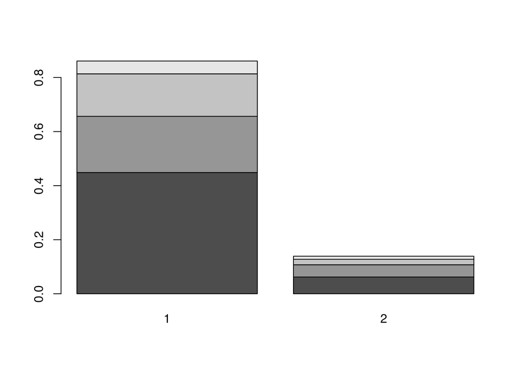

```r
## Make the corresponding barplot
barplot( prop.table(table(ETHCLASS, DIABETES)) )
```

```r
## Or we can make the columns sum to one
prop.table( table(ETHCLASS, DIABETES), 2)
```

```
##         DIABETES
## ETHCLASS          1          2
##        1 0.52099738 0.44715447
##        2 0.24146982 0.32520325
##        3 0.18241470 0.14634146
##        9 0.05511811 0.08130081
```

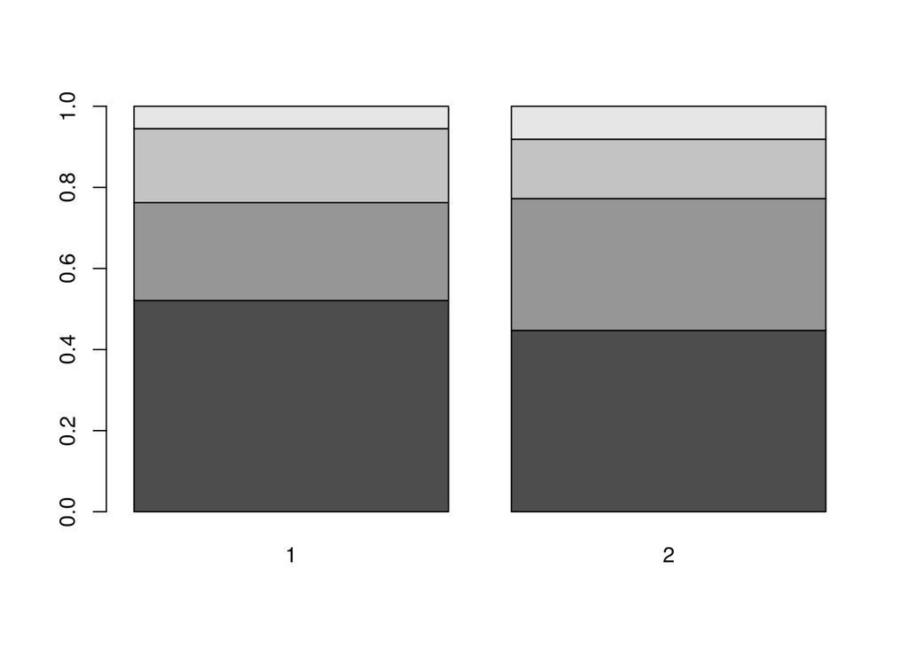

```r
barplot( prop.table(table(ETHCLASS, DIABETES), 2) )
```

## Density plots

- Sometines it is useful to represent continuous data as a density, rather than a histogram.

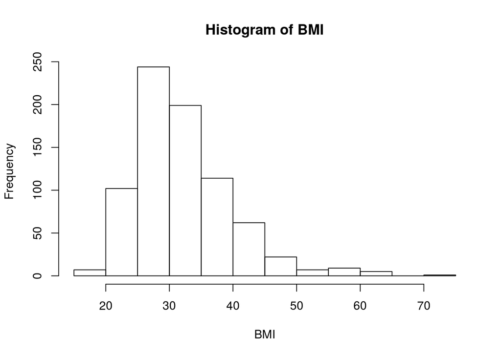

```r
## Histogram of BMI data
hist(BMI)
```

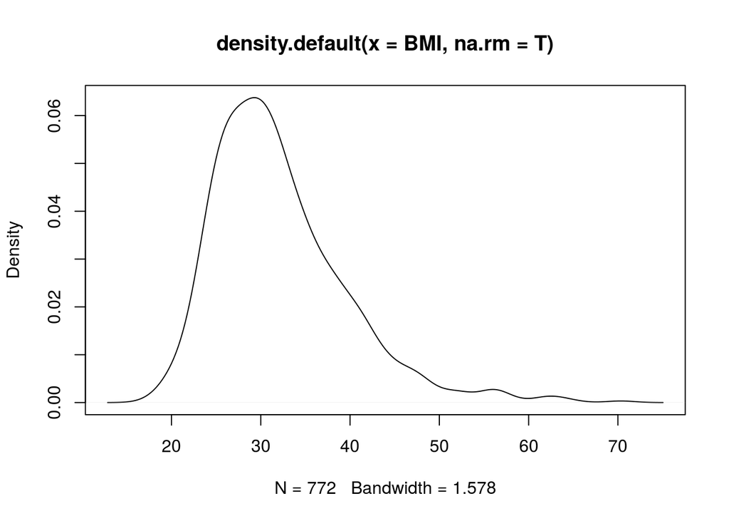

```r
## Density plot of BMI data
## Note: have to remove NA values, or the density() function gives an error.
plot( density(BMI, na.rm = T) )
```

## Multiple plots per page

- Arranging multiple plots on a single figure can be useful
- In base R graphics this is accomplished using either the `mfrow()` or `mfcol()` functions.
- both specify a grid of plots: which function you use depends on the order in which you want to generate the plots.
- `mfrow()` fills the grid row-by-row (left to right)
- `mfcol()` fills the grid column-by-column (top to bottom)

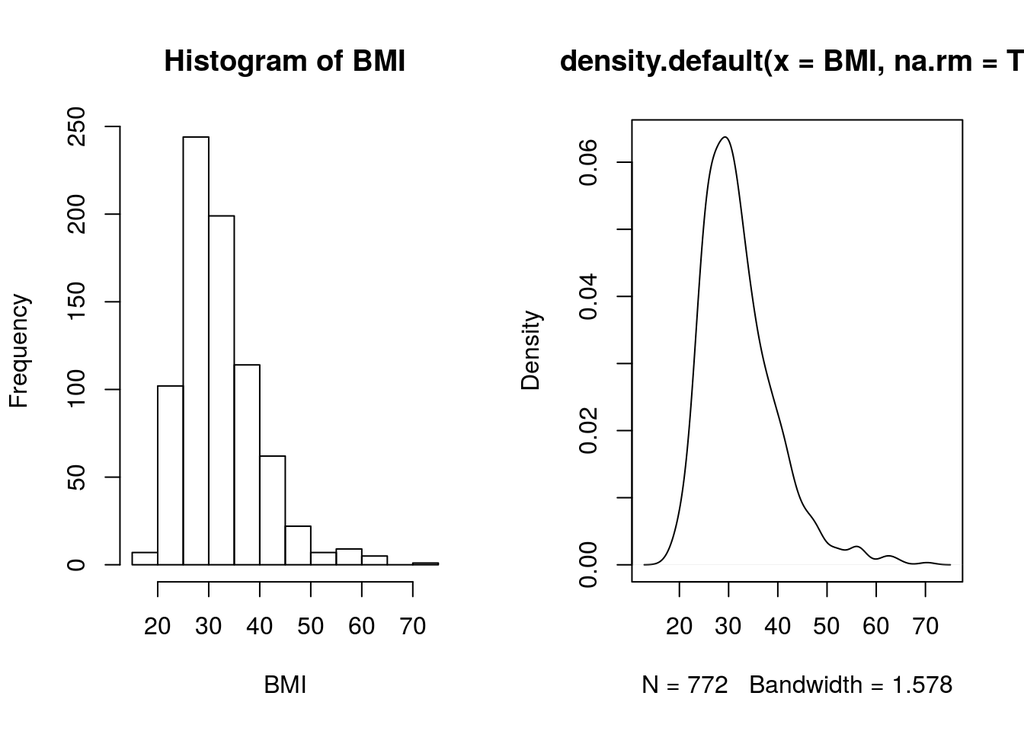

```r
## Specify a 1 x 2 (1 row, 2 columns) grid of plots, and fill by rows, left to right
par(mfrow = c(1, 2))

## Place a histogram of BMI in the first cell of the first row
hist(BMI)

## Place a density plot of BMI in the second cell of the first row
plot(density(BMI, na.rm=T))
```

## Saving plots

- R can output graphics in a number of formats: pdf, jpeg, png etc
- In RStudio you can also save your plots via the “Export” menu in the “Plots” tab.
- The following code opens a PDF file, writes a histogram to that file, and then closes the connection to the file.

```r
## Open PDF file for writing, and specify dimensions
## Note that PDF files use dimensions based on inches, whereas png and
## jpeg files use pixels
pdf(file = 'bmi_histogram.pdf', height = 6, width = 6)

## Write histogram of BMI to file
hist(BMI)

## Close the file
dev.off()
```

```r
## For multi-plot figures, you need to adjust the dimensions
pdf(file = 'bmi_histogram_density.pdf', height = 6, width = 12)
par(mfrow = c(1, 2))
hist(BMI)
plot(density(BMI, na.rm=T))
dev.off()
```